# 326.212 Homework 2

DongWon Kim

## 2020-13483

```r
library("tidyverse")
library("nycflights13")
```

### Textbook 5.2.4

#### Problem 1.

Find all flights that

1.Had an arrival delay of two or more hours 2.Flew to Houston (IAH or HOU) 3.Were operated by United, American, or Delta 4.Departed in summer (July, August, and September) 5.Arrived more than two hours late, but didn’t leave late 6.Were delayed by at least an hour, but made up over 30 minutes in flight 7.Departed between midnight and 6am (inclusive)

```r
filter(flights, arr_delay>=120)
```

```
## # A tibble: 10,200 x 19
##     year month   day dep_time sched_dep_time dep_delay arr_time sched_arr_time
##    <int> <int> <int>    <int>          <int>     <dbl>    <int>          <int>
##  1  2013     1     1      811            630       101     1047            830
##  2  2013     1     1      848           1835       853     1001           1950
##  3  2013     1     1      957            733       144     1056            853
##  4  2013     1     1     1114            900       134     1447           1222
##  5  2013     1     1     1505           1310       115     1638           1431
##  6  2013     1     1     1525           1340       105     1831           1626
##  7  2013     1     1     1549           1445        64     1912           1656
##  8  2013     1     1     1558           1359       119     1718           1515
##  9  2013     1     1     1732           1630        62     2028           1825
## 10  2013     1     1     1803           1620       103     2008           1750
## # ... with 10,190 more rows, and 11 more variables: arr_delay <dbl>,
## #   carrier <chr>, flight <int>, tailnum <chr>, origin <chr>, dest <chr>,
## #   air_time <dbl>, distance <dbl>, hour <dbl>, minute <dbl>, time_hour <dttm>
```

```r
filter(flights, dest=="IAH" | dest == "HOU" )
```

```
## # A tibble: 9,313 x 19
##     year month   day dep_time sched_dep_time dep_delay arr_time sched_arr_time
##    <int> <int> <int>    <int>          <int>     <dbl>    <int>          <int>
##  1  2013     1     1      517            515         2      830            819
##  2  2013     1     1      533            529         4      850            830
##  3  2013     1     1      623            627        -4      933            932
##  4  2013     1     1      728            732        -4     1041           1038
##  5  2013     1     1      739            739         0     1104           1038
##  6  2013     1     1      908            908         0     1228           1219
##  7  2013     1     1     1028           1026         2     1350           1339
##  8  2013     1     1     1044           1045        -1     1352           1351
##  9  2013     1     1     1114            900       134     1447           1222
## 10  2013     1     1     1205           1200         5     1503           1505
## # ... with 9,303 more rows, and 11 more variables: arr_delay <dbl>,
## #   carrier <chr>, flight <int>, tailnum <chr>, origin <chr>, dest <chr>,
## #   air_time <dbl>, distance <dbl>, hour <dbl>, minute <dbl>, time_hour <dttm>
```

```r
airlines # 항공사들의 이름
```

```
## # A tibble: 16 x 2
##    carrier name
##    <chr>   <chr>
##  1 9E      Endeavor Air Inc.
##  2 AA      American Airlines Inc.
##  3 AS      Alaska Airlines Inc.
##  4 B6      JetBlue Airways
##  5 DL      Delta Air Lines Inc.
##  6 EV      ExpressJet Airlines Inc.
##  7 F9      Frontier Airlines Inc.
##  8 FL      AirTran Airways Corporation
##  9 HA      Hawaiian Airlines Inc.
## 10 MQ      Envoy Air
## 11 OO      SkyWest Airlines Inc.
## 12 UA      United Air Lines Inc.
## 13 US      US Airways Inc.
## 14 VX      Virgin America
## 15 WN      Southwest Airlines Co.
## 16 YV      Mesa Airlines Inc.
```

```r
filter(flights, carrier == "UA" |carrier == "AA" |carrier == "DL" )
```

```
## # A tibble: 139,504 x 19
##     year month   day dep_time sched_dep_time dep_delay arr_time sched_arr_time
##    <int> <int> <int>    <int>          <int>     <dbl>    <int>          <int>
##  1  2013     1     1      517            515         2      830            819
##  2  2013     1     1      533            529         4      850            830
##  3  2013     1     1      542            540         2      923            850
##  4  2013     1     1      554            600        -6      812            837
##  5  2013     1     1      554            558        -4      740            728
##  6  2013     1     1      558            600        -2      753            745
##  7  2013     1     1      558            600        -2      924            917
##  8  2013     1     1      558            600        -2      923            937
##  9  2013     1     1      559            600        -1      941            910
## 10  2013     1     1      559            600        -1      854            902
## # ... with 139,494 more rows, and 11 more variables: arr_delay <dbl>,
## #   carrier <chr>, flight <int>, tailnum <chr>, origin <chr>, dest <chr>,
## #   air_time <dbl>, distance <dbl>, hour <dbl>, minute <dbl>, time_hour <dttm>
```

```r
filter(flights, month == 7|month == 8|month == 9)
```

```
## # A tibble: 86,326 x 19
##     year month   day dep_time sched_dep_time dep_delay arr_time sched_arr_time
##    <int> <int> <int>    <int>          <int>     <dbl>    <int>          <int>
##  1  2013     7     1        1           2029       212      236           2359
##  2  2013     7     1        2           2359         3      344            344
##  3  2013     7     1       29           2245       104      151              1
##  4  2013     7     1       43           2130       193      322             14
##  5  2013     7     1       44           2150       174      300            100
##  6  2013     7     1       46           2051       235      304           2358
##  7  2013     7     1       48           2001       287      308           2305
##  8  2013     7     1       58           2155       183      335             43
##  9  2013     7     1      100           2146       194      327             30
## 10  2013     7     1      100           2245       135      337            135
## # ... with 86,316 more rows, and 11 more variables: arr_delay <dbl>,
## #   carrier <chr>, flight <int>, tailnum <chr>, origin <chr>, dest <chr>,
## #   air_time <dbl>, distance <dbl>, hour <dbl>, minute <dbl>, time_hour <dttm>
```

```r
filter(flights, arr_delay>120 & dep_delay <=0 )
```

```
## # A tibble: 29 x 19
##     year month   day dep_time sched_dep_time dep_delay arr_time sched_arr_time
##    <int> <int> <int>    <int>          <int>     <dbl>    <int>          <int>
##  1  2013     1    27     1419           1420        -1     1754           1550
##  2  2013    10     7     1350           1350         0     1736           1526
##  3  2013    10     7     1357           1359        -2     1858           1654
##  4  2013    10    16      657            700        -3     1258           1056
##  5  2013    11     1      658            700        -2     1329           1015
##  6  2013     3    18     1844           1847        -3       39           2219
##  7  2013     4    17     1635           1640        -5     2049           1845
##  8  2013     4    18      558            600        -2     1149            850
##  9  2013     4    18      655            700        -5     1213            950
## 10  2013     5    22     1827           1830        -3     2217           2010
## # ... with 19 more rows, and 11 more variables: arr_delay <dbl>, carrier <chr>,
## #   flight <int>, tailnum <chr>, origin <chr>, dest <chr>, air_time <dbl>,
## #   distance <dbl>, hour <dbl>, minute <dbl>, time_hour <dttm>
```

```r
filter(flights, dep_delay>=60  & dep_delay -  arr_delay > 30 )
```

```
## # A tibble: 1,844 x 19
##     year month   day dep_time sched_dep_time dep_delay arr_time sched_arr_time
##    <int> <int> <int>    <int>          <int>     <dbl>    <int>          <int>
##  1  2013     1     1     2205           1720       285       46           2040
##  2  2013     1     1     2326           2130       116      131             18
##  3  2013     1     3     1503           1221       162     1803           1555
##  4  2013     1     3     1839           1700        99     2056           1950
##  5  2013     1     3     1850           1745        65     2148           2120
##  6  2013     1     3     1941           1759       102     2246           2139
##  7  2013     1     3     1950           1845        65     2228           2227
##  8  2013     1     3     2015           1915        60     2135           2111
##  9  2013     1     3     2257           2000       177       45           2224
## 10  2013     1     4     1917           1700       137     2135           1950
## # ... with 1,834 more rows, and 11 more variables: arr_delay <dbl>,
## #   carrier <chr>, flight <int>, tailnum <chr>, origin <chr>, dest <chr>,
## #   air_time <dbl>, distance <dbl>, hour <dbl>, minute <dbl>, time_hour <dttm>
```

```r
filter(flights, dep_time <=600| dep_time==2400  )
```

```
## # A tibble: 9,373 x 19
##     year month   day dep_time sched_dep_time dep_delay arr_time sched_arr_time
##    <int> <int> <int>    <int>          <int>     <dbl>    <int>          <int>
##  1  2013     1     1      517            515         2      830            819
##  2  2013     1     1      533            529         4      850            830
##  3  2013     1     1      542            540         2      923            850
##  4  2013     1     1      544            545        -1     1004           1022
##  5  2013     1     1      554            600        -6      812            837
##  6  2013     1     1      554            558        -4      740            728
##  7  2013     1     1      555            600        -5      913            854
##  8  2013     1     1      557            600        -3      709            723
##  9  2013     1     1      557            600        -3      838            846
## 10  2013     1     1      558            600        -2      753            745
## # ... with 9,363 more rows, and 11 more variables: arr_delay <dbl>,
## #   carrier <chr>, flight <int>, tailnum <chr>, origin <chr>, dest <chr>,
## #   air_time <dbl>, distance <dbl>, hour <dbl>, minute <dbl>, time_hour <dttm>
```

#### Problem 3. How many flights have a missing dep_time? What other variables are missing? What might these rows represent?

```r
filter(flights, is.na(dep_time))
```

```
## # A tibble: 8,255 x 19
##     year month   day dep_time sched_dep_time dep_delay arr_time sched_arr_time
##    <int> <int> <int>    <int>          <int>     <dbl>    <int>          <int>
##  1  2013     1     1       NA           1630        NA       NA           1815
##  2  2013     1     1       NA           1935        NA       NA           2240
##  3  2013     1     1       NA           1500        NA       NA           1825
##  4  2013     1     1       NA            600        NA       NA            901
##  5  2013     1     2       NA           1540        NA       NA           1747
##  6  2013     1     2       NA           1620        NA       NA           1746
##  7  2013     1     2       NA           1355        NA       NA           1459
##  8  2013     1     2       NA           1420        NA       NA           1644
##  9  2013     1     2       NA           1321        NA       NA           1536
## 10  2013     1     2       NA           1545        NA       NA           1910
## # ... with 8,245 more rows, and 11 more variables: arr_delay <dbl>,
## #   carrier <chr>, flight <int>, tailnum <chr>, origin <chr>, dest <chr>,
## #   air_time <dbl>, distance <dbl>, hour <dbl>, minute <dbl>, time_hour <dttm>
```

8255개의 비행기에서 `dep_time`이 누락되었다. 이 뿐만 아니라 `dep_delay`, `arr_time`, `arr_delay`, `air_time`이 누락된 것을 확인할 수 있었다. 아마 이 비행기들은 비행이 취소된 비행기 일 것이다.

### Textbook 5.3.1 How could you use arrange() to sort all missing values to the start? (Hint: use is.na()).

#### Problem 1.

```r
df <- tibble(x = c(5, 2, NA))
arrange(df, x)
```

```
## # A tibble: 3 x 1
##       x
##   <dbl>
## 1     2
## 2     5
## 3    NA
```

```r
arrange(df, desc(is.na(x)))
```

```
## # A tibble: 3 x 1
##       x
##   <dbl>
## 1    NA
## 2     5
## 3     2
```

예시로 `df <- tibble(x = c(5, 2, NA))` 이용해볼 것이다. 첫번째 처럼 desc를 써주지 않으면 2부터 시작함을 알 수 있다. 우리가 원하는 것은 `NA`가 가장 앞에 오는 것이므로 desc()와 is.na()를 활용해주면 된다. 이렇게 되면 `NA`가 가장 앞에 정렬됨을 확인할 수 있다.

### Textbook 5.4.1

#### Problem 4. Does the result of running the following code surprise you? How do the select helpers deal with case by default? How can you change that default?

```r
select(flights, contains("TIME"))
```

```
## # A tibble: 336,776 x 6
##    dep_time sched_dep_time arr_time sched_arr_time air_time time_hour
##       <int>          <int>    <int>          <int>    <dbl> <dttm>
##  1      517            515      830            819      227 2013-01-01 05:00:00
##  2      533            529      850            830      227 2013-01-01 05:00:00
##  3      542            540      923            850      160 2013-01-01 05:00:00
##  4      544            545     1004           1022      183 2013-01-01 05:00:00
##  5      554            600      812            837      116 2013-01-01 06:00:00
##  6      554            558      740            728      150 2013-01-01 05:00:00
##  7      555            600      913            854      158 2013-01-01 06:00:00
##  8      557            600      709            723       53 2013-01-01 06:00:00
##  9      557            600      838            846      140 2013-01-01 06:00:00
## 10      558            600      753            745      138 2013-01-01 06:00:00
## # ... with 336,766 more rows
```

```r
select(flights, contains("TIME", ignore.case = FALSE))
```

```
## # A tibble: 336,776 x 0
```

분명 `contains("TIME")`은 대문자인데 대문자/소문자 관계없이 문자 ’time’이 열 이름에 들어가있으면 그 열들을 다 `select`해서 아주 조금 놀랐다. `?contains` 결과 ’ignore.case = FALSE`하면 디폴트를 변경할 수 있다는 것을 알 수 있었다.

### Textbook 5.5.2

#### Problem 1.Currently dep_time and sched_dep_time are convenient to look at, but hard to compute with because they’re not really continuous numbers. Convert them to a more convenient representation of number of minutes since midnight.

```r
a<-select(flights, dep_time,sched_dep_time)
mutate(a, new_dep_time =((a$dep_time%/%100)*60+a$dep_time%%100)%%1440,
       sched_new_dep_time=((a$sched_dep_time%/%100)*60+a$sched_dep_time%%100)%%1440)
```

```
## # A tibble: 336,776 x 4
##    dep_time sched_dep_time new_dep_time sched_new_dep_time
##       <int>          <int>        <dbl>              <dbl>
##  1      517            515          317                315
##  2      533            529          333                329
##  3      542            540          342                340
##  4      544            545          344                345
##  5      554            600          354                360
##  6      554            558          354                358
##  7      555            600          355                360
##  8      557            600          357                360
##  9      557            600          357                360
## 10      558            600          358                360
## # ... with 336,766 more rows
```

덧붙이자면, flights에서 midnight는 2400으로 표시되며, 이를 분으로 고쳐주면 1440이다. 문제에 따르면 이 값은 0이 되어야한다. 그러므로 구한 식에 `%%1440`을 해주어야지 문제 조건을 만족시킬 수 있다.

#### Problem 3.Compare dep_time, sched_dep_time, and dep_delay. How would you expect those three numbers to be related?

```r
b<-select(flights, dep_time,sched_dep_time,dep_delay )
mutate(b,new_dep_time =((b$dep_time%/%100)*60+b$dep_time%%100)%%1440,
sched_new_dep_time=((b$sched_dep_time%/%100)*60+b$sched_dep_time%%100)%%1440,
new_dep_delay = new_dep_time-sched_new_dep_time)
```

```
## # A tibble: 336,776 x 6
##    dep_time sched_dep_time dep_delay new_dep_time sched_new_dep_t~ new_dep_delay
##       <int>          <int>     <dbl>        <dbl>            <dbl>         <dbl>
##  1      517            515         2          317              315             2
##  2      533            529         4          333              329             4
##  3      542            540         2          342              340             2
##  4      544            545        -1          344              345            -1
##  5      554            600        -6          354              360            -6
##  6      554            558        -4          354              358            -4
##  7      555            600        -5          355              360            -5
##  8      557            600        -3          357              360            -3
##  9      557            600        -3          357              360            -3
## 10      558            600        -2          358              360            -2
## # ... with 336,766 more rows
```

열의 이름에서 `dep_time - sche_dep__time = dep_delay`임을 유추할 수 있는데, 정확한 계산을 위해서는 1번 문제를 활용해야한다. 1번 문제를 통해 출발 시각과 예정 출발 시각을 자정에서 몇 분 지났는가로 고쳐준 다음에 이 둘을 빼주면 원래 flights에서 `dep_delay`와 같은 값을 같은 것을 확인할 수 있었다. 고쳐주는 이유는 원래 `flights`에서는 보기 편한 상태로 출발시각과 예정된 출발시각을 나타냈기 때문이다.

### Textbook 5.6.7

#### Problem 5.Which carrier has the worst delays? Challenge: can you disentangle the effects of bad airports vs. bad carriers? Why/why not? (Hint: think about flights %>% group_by(carrier, dest) %>% summarise(n())

```r
flights %>% group_by(carrier) %>% summarise(delay=mean(arr_delay - dep_delay, na.rm = T))%>% arrange(desc(delay))
```

```
## # A tibble: 16 x 2
##    carrier   delay
##    <chr>     <dbl>
##  1 F9        1.72
##  2 FL        1.51
##  3 MQ        0.329
##  4 OO       -0.655
##  5 US       -1.62
##  6 YV       -3.34
##  7 B6       -3.51
##  8 EV       -4.04
##  9 DL       -7.58
## 10 WN       -8.01
## 11 AA       -8.20
## 12 UA       -8.46
## 13 9E       -9.06
## 14 VX      -11.0
## 15 HA      -11.8
## 16 AS      -15.8
```

```r
airlines
```

```
## # A tibble: 16 x 2
##    carrier name
##    <chr>   <chr>
##  1 9E      Endeavor Air Inc.
##  2 AA      American Airlines Inc.
##  3 AS      Alaska Airlines Inc.
##  4 B6      JetBlue Airways
##  5 DL      Delta Air Lines Inc.
##  6 EV      ExpressJet Airlines Inc.
##  7 F9      Frontier Airlines Inc.
##  8 FL      AirTran Airways Corporation
##  9 HA      Hawaiian Airlines Inc.
## 10 MQ      Envoy Air
## 11 OO      SkyWest Airlines Inc.
## 12 UA      United Air Lines Inc.
## 13 US      US Airways Inc.
## 14 VX      Virgin America
## 15 WN      Southwest Airlines Co.
## 16 YV      Mesa Airlines Inc.
```

```r
flights %>%
  filter(!is.na(arr_delay - dep_delay))%>%
  group_by(carrier, dest, origin) %>% summarise(fly_delay=sum(arr_delay - dep_delay), flights= n())%>% group_by(dest,origin)%>%
  mutate(fly_delay_sum = sum(fly_delay), flights_sum= sum(flights))%>%
  ungroup()%>%
  mutate(fly_delay_fly= fly_delay/flights, rest_delay_fly= (fly_delay_sum)/(flights_sum), comp_fly_delay = fly_delay_fly - rest_delay_fly) %>%
  group_by(carrier)%>%
  summarise(final_delay_delay = mean(comp_fly_delay))
```

```
## # A tibble: 16 x 2
##    carrier final_delay_delay
##    <chr>               <dbl>
##  1 9E                -0.740
##  2 AA                -0.0868
##  3 AS                -2.60
##  4 B6                 1.81
##  5 DL                -2.50
##  6 EV                -0.688
##  7 F9                 6.92
##  8 FL                 4.21
##  9 HA                 0
## 10 MQ                 3.77
## 11 OO                14.2
## 12 UA                 0.233
## 13 US                 1.37
## 14 VX                 1.46
## 15 WN                -1.44
## 16 YV                -5.52
```

`carrier`만 놓고 보았을때 `F9`이라는 이름을 가진 Frontier Airlines Inc.이 가장 나쁜 지연을 보이고 있다.하지만 이러한 결과는 나쁜 공항에 의해 영향을 받았을수 있음을 생각해볼 수 있다. 완전히는 아니지만 공항과 `carrier`가 미치는 영향을 분리할 수 있을 것이며, 최대한 결과가 공항에 의한 영향을 덜 받도록 코드를 다시 짜볼 것이다. 우선 나쁜공항에 의한 영향을 가장 간단히 최소화 시키는 방법은 동일한 루트에서 `carrier`들을 비교하는 것이다. 즉, 각 루트에서 각 `carrier`마다의 지연시간 평균과 각 루트에서 모든 `carrier` 지연시간 평균의 차를 비교해주면 보다 정확하게 가장 나쁜 지연을 보여주는 `carrier`를 찾을 수 있다고 생각한다. 이에 맞추어 코드를 짜본 결과 `OO`이라는 이름을 가진SkyWest Airlines Inc.이 가장 나쁜 지연을 보이고 있다.

### Textbook 5.7.1

#### Problem 5.Delays are typically temporally correlated: even once the problem that caused the initial delay has been resolved, later flights are delayed to allow earlier flights to leave. Using lag(), explore how the delay of a flight is related to the delay of the immediately preceding flight.

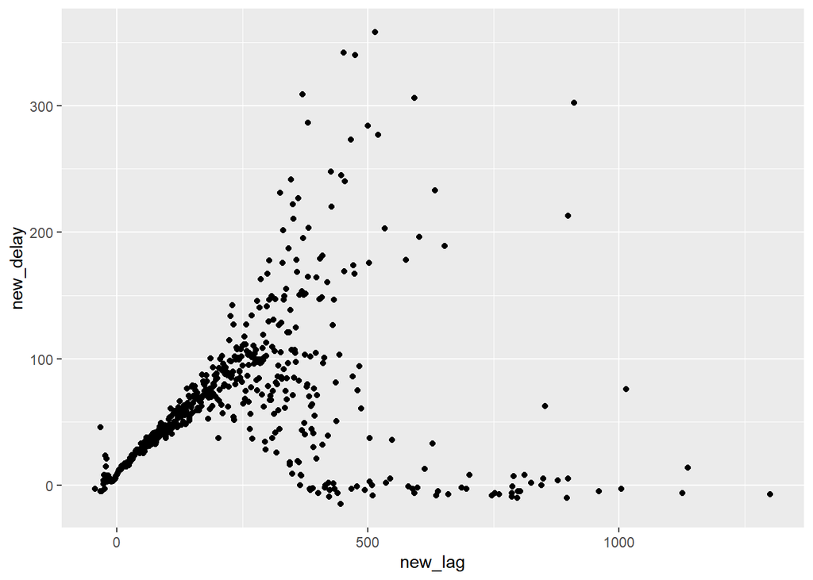

```r
really_late<-flights%>%
  filter(!is.na(dep_delay))  %>% arrange(origin, year, month, day, dep_time)%>%group_by(origin) %>% mutate(new_lag = lag(dep_delay))%>%filter(!is.na(new_lag))

really_late %>% group_by(new_lag)%>%summarise(new_delay = mean(dep_delay))%>%ggplot()+geom_point(mapping =aes(x= new_lag, y=new_delay) )
```

### Textbook 7.3.4

#### Problem 2.Explore the distribution of price. Do you discover anything unusual or surprising? (Hint: Carefully think about the binwidth and make sure you try a wide range of values.)

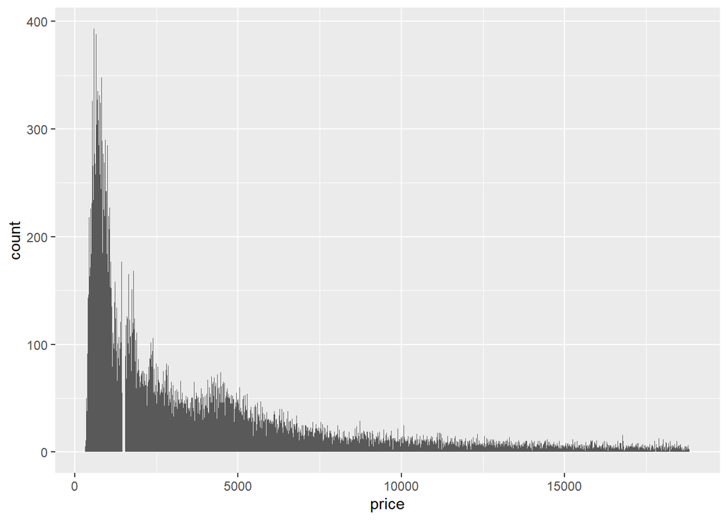

```r
ggplot(data = diamonds) +
  geom_histogram(mapping = aes(x = price), binwidth = 10)
```

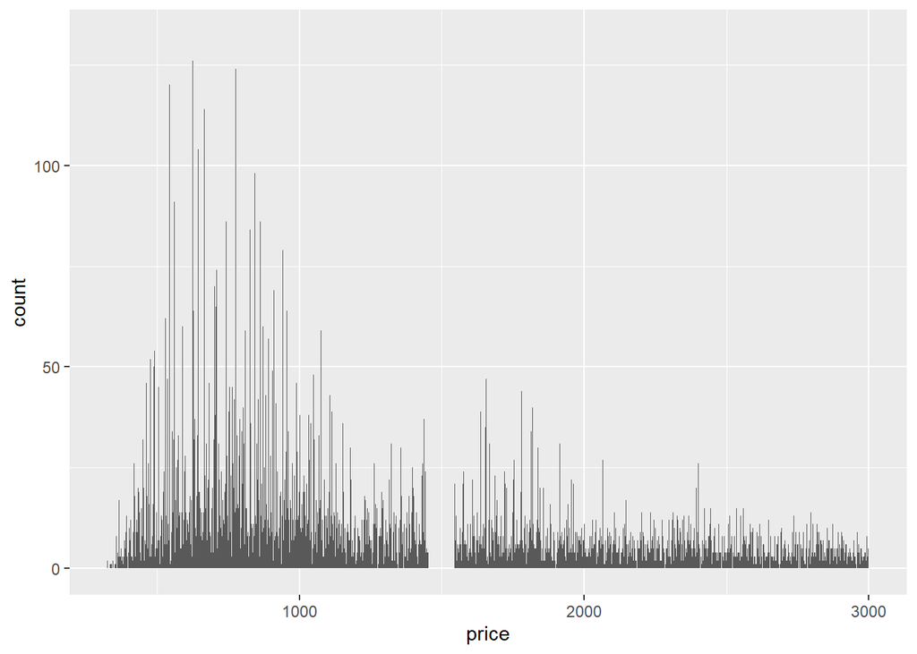

```r
ggplot(data = filter(diamonds, price <3000)) +
  geom_histogram(mapping = aes(x = price), binwidth = 1)
```

`binwidth` 를 10으로 한 결과 0~5000사이에 관측치가 존재하지 않는 곳이 있다는 특징이 있음을 확인할 수 있었다. 정확히 어디 구간인지 살펴보고자 `filter`를 활용했고, 이 관측치가 존재하지 않는 부분은 1500 근처임을 확인할 수 있었다.

### Textbook 7.5.1.1

#### Problem 1.Use what you’ve learned to improve the visualisation of the departure times of cancelled vs. non-cancelled flights.

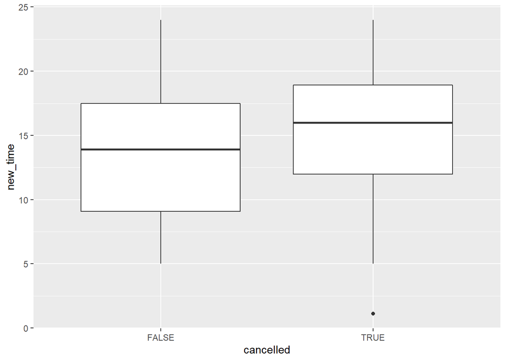

```r
ggplot( data = mutate(flights, cancelled = is.na(dep_time), new_time= hour+ minute/60))+
  geom_boxplot(mapping = aes(x = cancelled, y = new_time))
```